# Task 11

Pakete datasets yra duomenų masyvas longley. Iš šio kintamųjų padarykite tiesinę regresiją, kur prognozuojamas kintamasis būtų GNP, o regresosius Employed. Jums reikia:

1.Įvertinti paprastosios tiesinės regresijos modelį. Pateikti modelio summary ir pakomentuoti ką reiškia gauti skaičiai. Kaip interpretuoti gautus rezultatus?

2.Padarykite modelio prognozes taškuose 62,65,68.

3.Išbrėžkite kintamųjų sklaidos diagramą kartu su tiesinės regresijos tiese ir naujomis prognozėmis. Grafiką pateikite su pilna legena, kurioje būtų nurodyti visi žymėjimai.

Kintamasis, kurio reišmes norima prognozuoti yra priklausomas kintamasis. Jis yra GNP. Kintamasis, pagal kurio reikšmes norima prognozuoti yra Employed (nepriklausomas kintamasis). GNP - Gross National product. Employed - number of people employed.

Pasižiūriu, kokius duomenis turime

```r
head(longley,n=2)
```

```
##      GNP.deflator     GNP Unemployed Armed.Forces Population Year Employed
## 1947         83.0 234.289      235.6        159.0    107.608 1947   60.323
## 1948         88.5 259.426      232.5        145.6    108.632 1948   61.122
```

Įsivedu kintamuosius

```r
GNP<-longley[,2]
Employed<-longley[,7]
```

Pasižiūriu, kaip atrodo šių kintamųjų grafikas bei patikrinu koreliaciją.

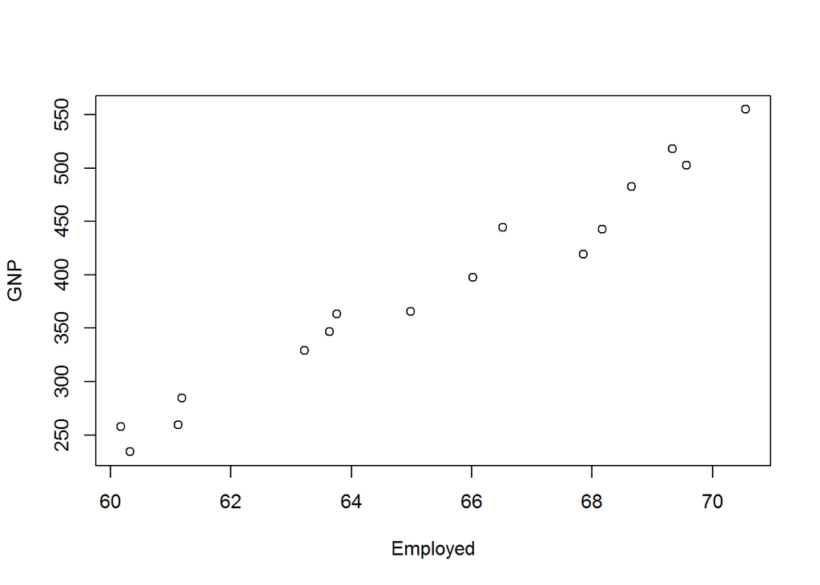

```r
plot(Employed,GNP)
```

```r
cor(Employed, GNP)
```

```
## [1] 0.9835516
```

Šių kintamųjų koreliacija yra didelė ( 0.9835516 ), kas reiškia, kad šių kintamųjų tiesinė priklausomybė yra stipri ir juos galima tiesiškai prognozuoti.

Dabar randame regresijos lygtį.

```r
lygtis<-lm(GNP~Employed)
lygtis
```

```
##
## Call:
## lm(formula = GNP ~ Employed)
##
## Coefficients:
## (Intercept)     Employed
##    -1430.48        27.84
```

Reiškia mūsų regresijos lygtis yra :

y=27.84*x-1430.48

Mūsų gauta regresijos lygtis atitinka duomenų išsibarstymą grafike:

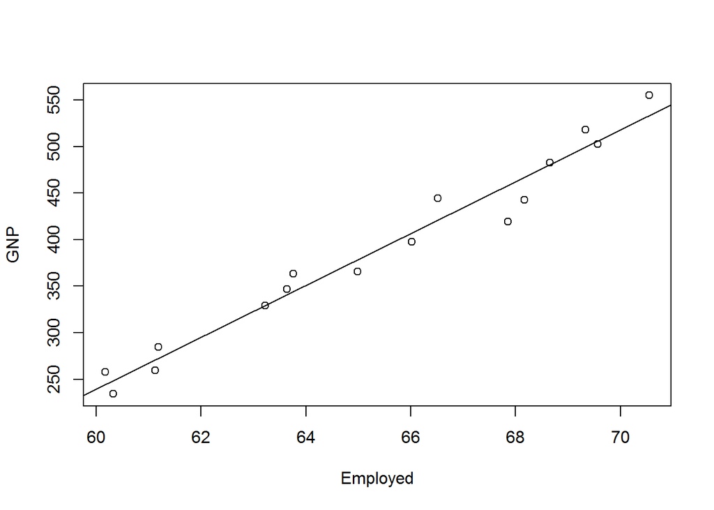

```r
plot(Employed, GNP)
abline(lygtis)
```

# Tiesinės regresijos prielaidos

1. Kad galėtume taikyti tiesinės regresijos modelį, liekamosios paklaidos turi būti normaliai pasiskirstę atsitiktiniai dydžiai. Tikrinam:

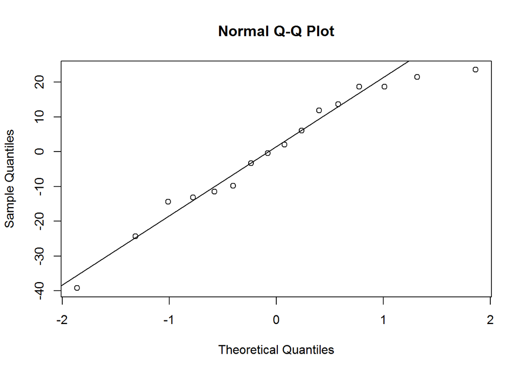

```r
qqnorm(lygtis$residuals)
qqline(lygtis$residuals)
```

Matome, kad liekamosios paklaidos yra normaliai pasiskirstę atsitiktiniai dydžiai. Jeigu mūsų paklaidos yra normaliai pasiskirsčiusios, iš to išplaukia, kad vidurkis skirtumo tarp turimų reikšmių ir spejamų reikšmių yra arti nulio. (tai yra gerai modeliui)

2. Visu liekamujų paklaidų vidurkiai lygūs nuliui o dispersijos lygios. Tikrinu:

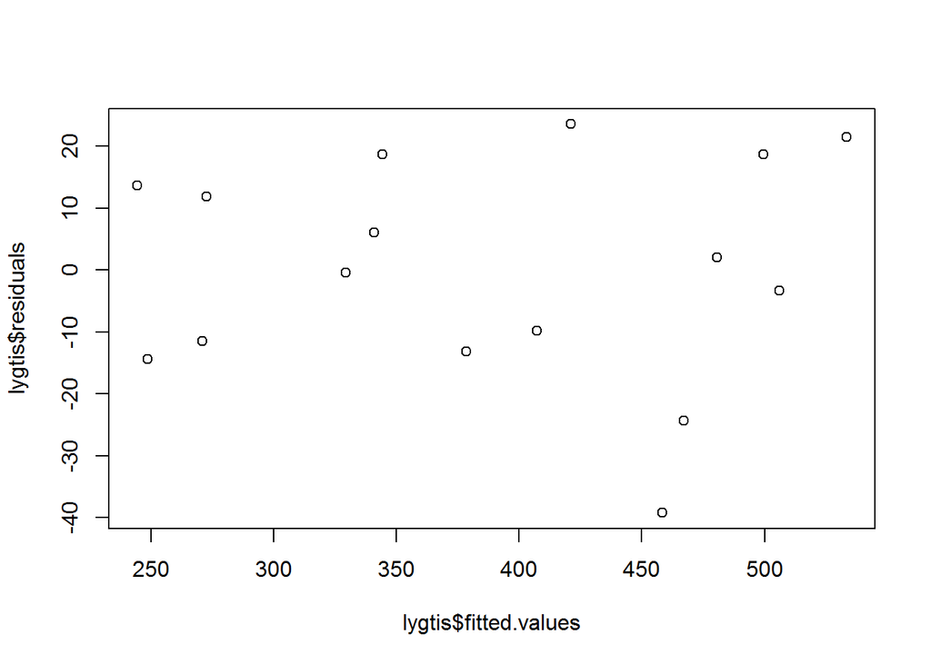

```r
 plot(lygtis$fitted.values,lygtis$residuals)
```

Jeigu, pavyzdžiui, paklaidos didėja arba mažėja su fiksuotomis reiksmėmis grafike , tai greičiausiai liekamujų paklaidų dispersijos nėra lygios. Iš grafiko matosi, kad reikšmės išsibarsciusios atsitiktinai apie nulį ir nėra dėsningumo.

3. Visos liekamosios paklaidos nepriklausomos

```r
library(lmtest)
dwtest(lygtis)
```

```
##
##  Durbin-Watson test
##
## data:  lygtis
## DW = 1.5298, p-value = 0.1008
## alternative hypothesis: true autocorrelation is greater than 0
```

Kuo DW arčiau 2, tuo mažiau tikėtina , kad autokoreliacija yra. Kadangi DW = 1.5298 yra (sąlyginai arti 2 ), tai autokoreliacija mažai tikėtina.

Modelio summary:

```r
summary(lygtis)
```

```
##
## Call:
## lm(formula = GNP ~ Employed)
##
## Residuals:
##     Min      1Q  Median      3Q     Max
## -39.223 -11.920   0.855  14.882  23.555
##
## Coefficients:
##              Estimate Std. Error t value Pr(>|t|)
## (Intercept) -1430.482     89.361  -16.01 2.15e-10 ***
## Employed       27.836      1.366   20.37 8.36e-12 ***
## ---
## Signif. codes:  0 '***' 0.001 '**' 0.01 '*' 0.05 '.' 0.1 ' ' 1
##
## Residual standard error: 18.58 on 14 degrees of freedom
## Multiple R-squared:  0.9674, Adjusted R-squared:  0.965
## F-statistic: 415.1 on 1 and 14 DF,  p-value: 8.363e-12
```

*Call:*

*lm(formula = GNP ~ Employed)*

Rodo, kaip sudaryta formulė (mūsų priklausomas kintamasis buvo GNP, nes jo reikšmes prognozuojame). Formulei sudaryti reikalingi tik priklausomas ir nepriklausomas kintamieji (GNP ir Employed)

*Residuals:*

*Min 1Q Median 3Q Max*

*-39.223 -11.920 0.855 14.882 23.555*

Residuals (liekamosios paklaidos) yra skirtumas tarp stebetu reikšmių ir reikšmių, kurias nuspėjo regresijos modelis. (formulė ei = GNP - (-1430.48+27.84*Employed, čia ei - i-toji liekamoji paklaida, -1430.48 ir 27.84 - apskaičiuoti lygties koeficientai)

*Coefficients:*

*Estimate Std. Error t value Pr(>|t|)*

*(Intercept) -1430.482 89.361 -16.01 2.15e-10* ***

*Employed 27.836 1.366 20.37 8.36e-12* ***

```r
summary(lygtis)$coefficients[1:2,1]
```

```
## (Intercept)    Employed
## -1430.48231    27.83626
```

Tai yra musu lygties koeficientai a,b, apskaičiuoti pagal regresiją.

```r
summary(lygtis)$coefficients[1:2,2]
```

```
## (Intercept)    Employed
##   89.360802    1.366259
```

Std. Error - sklaidos matas, kuris nusako sklaidą apie mūsų apskaičiuotus a ir b koeficientus. Mūsų atveju standard errors yra atitinkamai 16 ir 20 mažesni nei apskaičiuoti koeficientai.

```r
summary(lygtis)$coefficients[1:2,3]
```

```
## (Intercept)    Employed
##   -16.00794    20.37407
```

t-value

Skirtos apskaičiuoti pasikliovimo lygmenį bei p reikšmes.

```r
summary(lygtis)$coefficients[1:2,4]
```

```
##  (Intercept)     Employed
## 2.146327e-10 8.363479e-12
```

p-value

Tikimybė, jog kintamieji yra nesusiję vienas su kitu. Šios reiksmės mums reikalingos kuo mažesnės - mūsų atveju jos yra labai mažos.

*Residual standard error: 18.58 on 14 degrees of freedom*

Paklaidų standartinis nuokrypis yra vidutinis dydis, kuriuo mūsų priklausomas kintamasis skirsis nuo tikrosios regresijos tiesės. Paklaidų standartinis nuokrypis buvo apskaičiuotas su 14 laisves laipsnių.

*Multiple R-squared: 0.9674, Adjusted R-squared: 0.965*

Tai matas, skirtas įvertinti modelio tinkamumą stebėjimams. Kuo didesnis skaičius - tuo modelis geresnis. Vienetas atitinka tobulą modelį, o mažiausia reikšmė - 0. Interpretacija: šiuo atveju apytiksliai 96 procentai GNP yra paaiškinami pagal Employed skaičių. (R-squared indikuoja aukstą koreliaciją, bet nebūtinai aukštą priežastingumą).

*F-statistic: 415.1 on 1 and 14 DF, p-value: 8.363e-12*

Indikatorius , nusakantis ryšį tarp priklausomo ir nepriklausomo kintamujų. Kuo toliau F-statistic yra nuo 1 , tuo geriau. Apskritai, kai turime didelį skaičių duomenų, F-statistic, kuri yra tik truputi didesnė nei 1, yra pakankamas indikatorius atmesti nulinę hipotezę, kuri sako, kad kintamieji neturi ryšio. Mūsų pavyzdyje F-statistic yra 415.1 ir yra pakankamai didesnė už 1, palyginus su mūsų duomenų kiekiu.

# 2. Padarykite modelio prognozes taškuose 62,65,68.

```r
x<-c(62,65,68)
y<-27.84*x-1430.48
y
```

```
## [1] 295.60 379.12 462.64
```

# 3. Išbrėžkite kintamųjų sklaidos diagramą kartu su tiesinės regresijos tiese ir naujomis prognozėmis. Grafiką pateikite su pilna legena, kurioje būtų nurodyti visi žymėjimai.

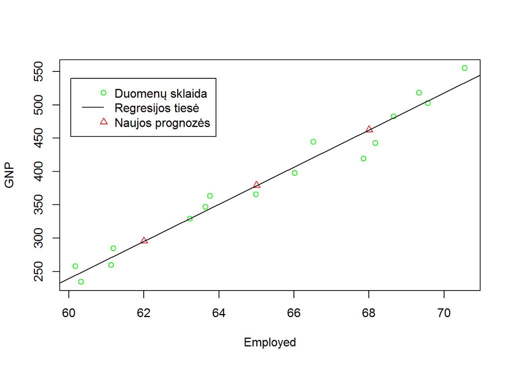

```r
plot(Employed, GNP,col="green",pch=1)
points(x,y,col="red", pch=2)
lines(abline(lygtis))
legend( 60.05,540, legend=c("Duomenų sklaida","Regresijos tiesė","Naujos prognozės"),
        col=c("green","black","red"), lty=c(NA,1,NA), pch=c(1,NA,2), merge=FALSE )
```